# problem 1

Ericka Smith

11/15/2020

#### Load data

```r
seizure <- read_table2("seizure.txt")
```

Notes on data: * 0 is placebo, 1 is progabride * y1, y2, y3, y4 are counts for seizures for each successive two weeks * base is number of seizures during baseline 8 wk period

### Part A

```r
mod <- glm(y4 ~ age+trt+base, family = "poisson", data = seizure)
summary(mod)
```

```
##
## Call:
## glm(formula = y4 ~ age + trt + base, family = "poisson", data = seizure)
##
## Deviance Residuals:
##     Min       1Q   Median       3Q      Max
## -3.1813  -0.9729  -0.2089   0.5932   3.9145
##
## Coefficients:
##              Estimate Std. Error z value Pr(>|z|)
## (Intercept)  0.728587   0.245920   2.963  0.00305 **
## age          0.015612   0.007159   2.181  0.02921 *
## trt         -0.278916   0.098866  -2.821  0.00479 **
## base         0.022153   0.001092  20.293  < 2e-16 ***
## ---
## Signif. codes:  0 '***' 0.001 '**' 0.01 '*' 0.05 '.' 0.1 ' ' 1
##
## (Dispersion parameter for poisson family taken to be 1)
##
##     Null deviance: 473.79  on 58  degrees of freedom
## Residual deviance: 144.57  on 55  degrees of freedom
## AIC: 340.83
##
## Number of Fisher Scoring iterations: 5
```

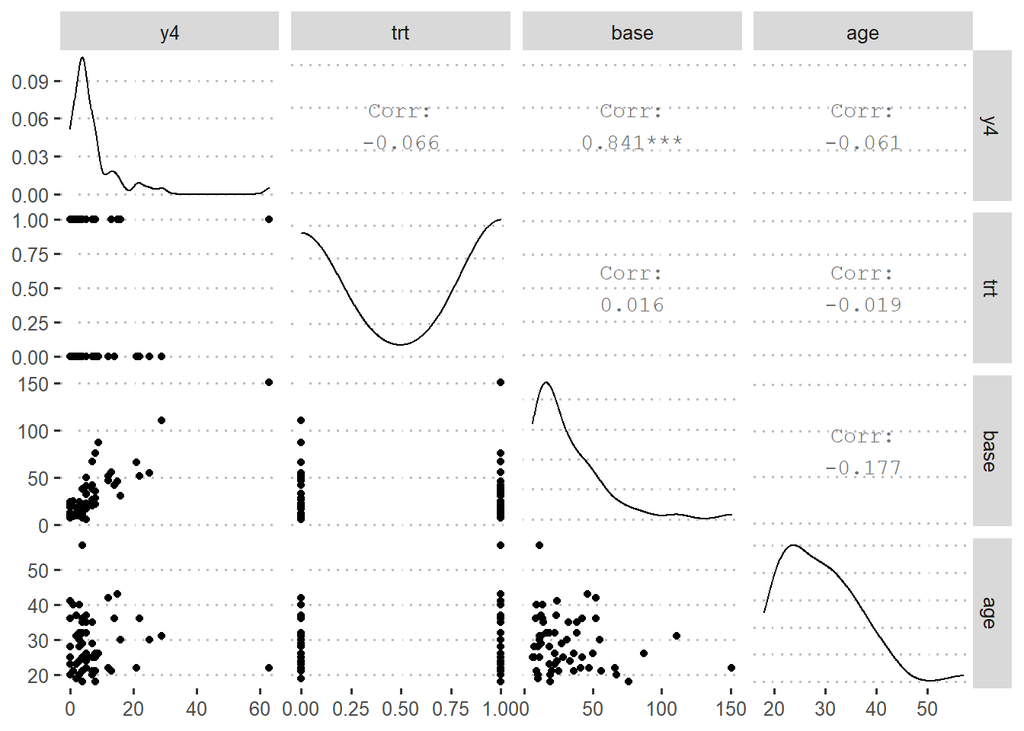

```r
ggpairs(seizure[,4:7])+theme_pubclean()
```

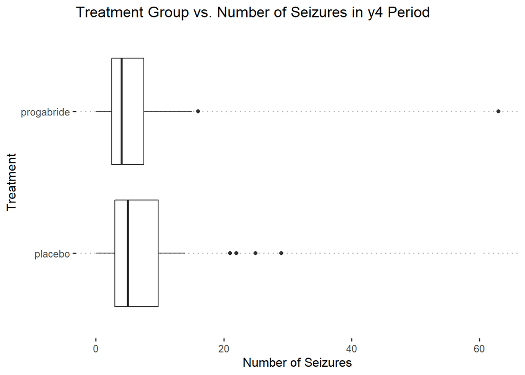

```r
ggplot(seizure, aes(y = as.factor(trt), x = y4, group=as.factor(trt)))+
  geom_boxplot()+
  theme_pubclean()+
  labs(title = "Treatment Group vs. Number of Seizures in y4 Period",
       x = "Number of Seizures",
       y = "Treatment")+
  scale_y_discrete(labels=c("0" = "placebo", "1" = "progabride"))
```

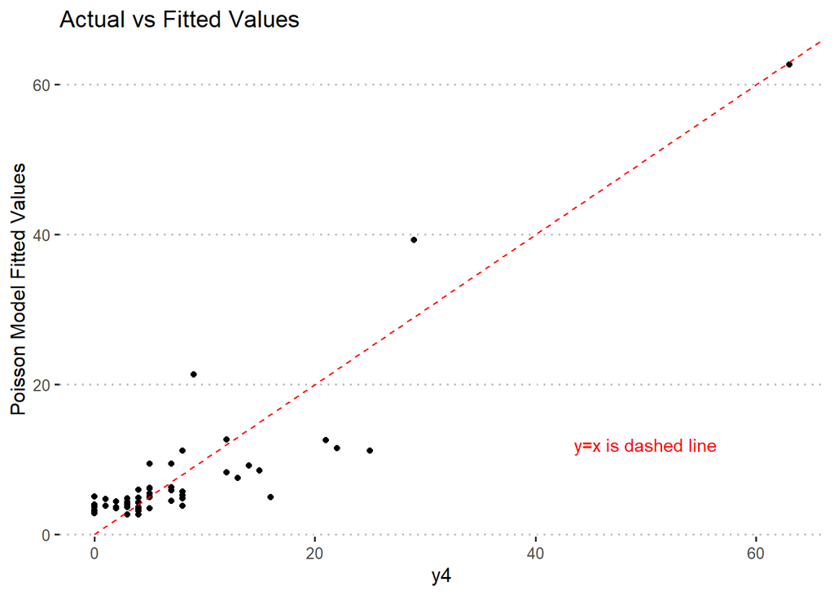

```r
ggplot()+
  geom_point(aes(x = seizure$y4, mod$fitted.values))+
  geom_abline(slope = 1, intercept = 0, color = "red", linetype= "dashed")+
  theme_pubclean()+
  labs(title = "Actual vs Fitted Values",
       x = "y4",
       y = "Poisson Model Fitted Values")+
  annotate("text", x=50, y=12, label="y=x is dashed line", color = "red")
```

My plots indicate that base is highly correlated with y4, which makes sense intuitively because frequency of seizures should at least somewhat rely on prior frequency of seizures. I was surprised to see that trt is significant (alpha = 0.05) in the model despite the fact that the boxplot indicates there isn’t a difference in means between the treatment and placebo groups. There a a bunch of reasons this could happen though, and so I defer to the model in this instance. The model gives age, trt, and base all as significant predictors of y4 (p=0.02921, p=0.00479, p< 2e-16, respectively). Based on the coefficients it appears that y4 increases with both age and base, but decreases with the treatment. Again though, just because it’s a significant predictor in the model does not clearly state that it is causing a decrease in seizures.

### Part B

Residual Analysis

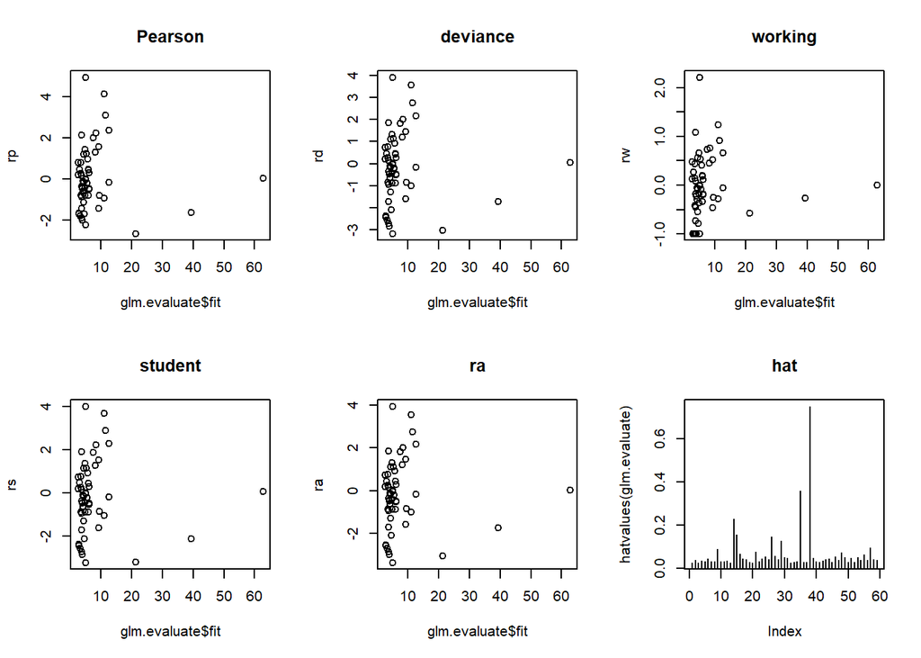

```r
glm.evaluate=mod

rp=resid(glm.evaluate, "pearson")
rd=resid(glm.evaluate, "deviance")
rw=resid(glm.evaluate, "working")
rs=rstudent(glm.evaluate)
ra=3*(glm.evaluate$y^{2/3}-glm.evaluate$fit^{2/3})/glm.evaluate$fit^{1/6}/2

par(mfrow=c(2,3))
plot(glm.evaluate$fit,rp, main="Pearson")
plot(glm.evaluate$fit,rd, main = "deviance")
plot(glm.evaluate$fit,rw, main="working")
plot(glm.evaluate$fit,rs, main="student")
plot(glm.evaluate$fit,ra, main="ra")
plot(hatvalues(glm.evaluate), type="h", main="hat")
```

The residual plots indicate that we have a few outliers. Without removing them it’s hard to say whether or not the rest of the residuals appear evenly and randomly distributed.

### Part C

```r
mod_nb <- glm.nb(y4 ~ age+trt+base, data=seizure)
summary(mod_nb)
```

```
##
## Call:
## glm.nb(formula = y4 ~ age + trt + base, data = seizure, init.theta = 4.919155396,
##     link = log)
##
## Deviance Residuals:
##     Min       1Q   Median       3Q      Max
## -2.5616  -0.7157  -0.1236   0.5451   2.5743
##
## Coefficients:
##              Estimate Std. Error z value Pr(>|z|)
## (Intercept)  0.636997   0.378339   1.684   0.0922 .
## age          0.014921   0.011134   1.340   0.1802
## trt         -0.317674   0.163840  -1.939   0.0525 .
## base         0.025374   0.002658   9.546   <2e-16 ***
## ---
## Signif. codes:  0 '***' 0.001 '**' 0.01 '*' 0.05 '.' 0.1 ' ' 1
##
## (Dispersion parameter for Negative Binomial(4.9192) family taken to be 1)
##
##     Null deviance: 181.952  on 58  degrees of freedom
## Residual deviance:  71.074  on 55  degrees of freedom
## AIC: 314.27
##
## Number of Fisher Scoring iterations: 1
##
##
##               Theta:  4.92
##           Std. Err.:  1.77
##
##  2 x log-likelihood:  -304.268
```

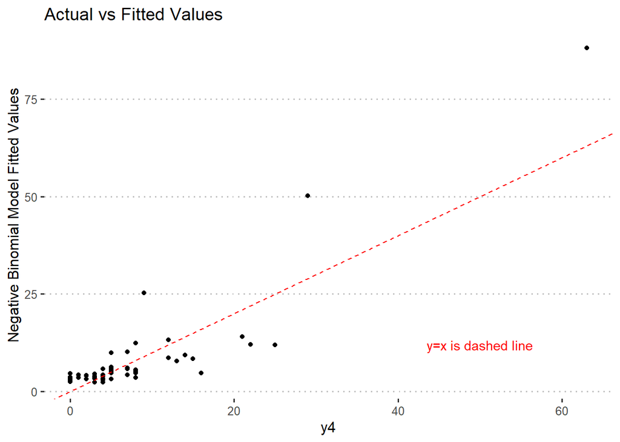

```r
ggplot()+
  geom_point(aes(x = seizure$y4, mod_nb$fitted.values))+
  geom_abline(slope = 1, intercept = 0, color = "red", linetype= "dashed")+
  theme_pubclean()+
  labs(title = "Actual vs Fitted Values",
       x = "y4",
       y = "Negative Binomial Model Fitted Values")+
  annotate("text", x=50, y=12, label="y=x is dashed line", color = "red")
```

Residual Analysis

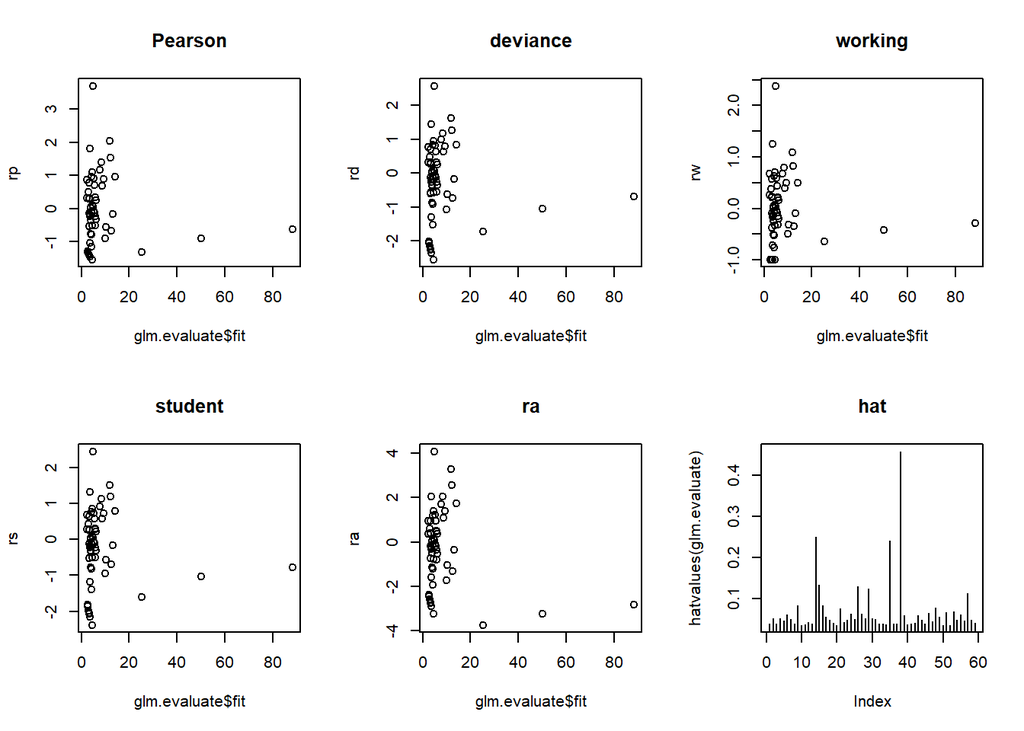

```r
glm.evaluate=mod_nb

rp=resid(glm.evaluate, "pearson")
rd=resid(glm.evaluate, "deviance")
rw=resid(glm.evaluate, "working")
rs=rstudent(glm.evaluate)
ra=3*(glm.evaluate$y^{2/3}-glm.evaluate$fit^{2/3})/glm.evaluate$fit^{1/6}/2

par(mfrow=c(2,3))
plot(glm.evaluate$fit,rp, main="Pearson")
plot(glm.evaluate$fit,rd, main = "deviance")
plot(glm.evaluate$fit,rw, main="working")
plot(glm.evaluate$fit,rs, main="student")
plot(glm.evaluate$fit,ra, main="ra")
plot(hatvalues(glm.evaluate), type="h", main="hat")
```

Based on the fitted values the model isn’t perfect, of course, but it provides a decent fit. The residuals indicate a few outliers so it’s difficult to stringently evaluate them, but overall they look okay. The model itself only names base as a significant predictor (p<2e-16). Trt is nearly significant at alpha = 0.05, with p= 0.0525. Age however is not even close, with p=0.1802. Base has a positive coefficient so we expect that more seizures at baseline is associated with more seizures during the y4 period. Age is the same (though not a good predictor), and trt is the opposite (though again, not significant predictor).

### Part D

Regardless I believe the negative binomial model is the better fit.